# Take Home Final Exam

For the take-home part of the MSDS 401 Final Exam, you are tasked with analyzing data on new daily covid-19 cases and deaths in European Union (EU) and European Economic Area (EEA) countries. A data file may be downloaded [here](https://www.ecdc.europa.eu/en/publications-data/data-daily-new-cases-covid-19-eueea-country), *or* you may use the provided **read.csv()** code in the ‘setup’ code chunk below to read the data directly from the web csv. Either approach is acceptable; the data should be the same.

Once you have defined a data frame with the daily case and death and country data, you are asked to: (1) perform an Exploratory Data Analysis (EDA), (2) perform some hypothesis testing, (3) perform some correlation testing, and (4) fit and describe a linear regression model. Each of these four (4) items is further explained below and “code chunks” have been created for you in which to add your R code, just as with the R and Data Analysis Assignments. You may add additional code chunks, as needed. You should make comments in the code chunks or add clarifying text between code chunks that you think further your work.

A data dictionary for the dataset is available [here](https://www.ecdc.europa.eu/sites/default/files/documents/Description-and-disclaimer_daily_reporting.pdf).

#### Definitions:

- “Incidence rate” is equal to new daily cases per 100K individuals. Country population estimates can be found in ‘popData2020.’ You will calculate a daily incidence rate in item (1), for each country, that we will explore further in items (2) and (3).
- “Fatality rate” is equal to new daily deaths per 100K individuals. Country population estimates can be found in ‘popData2020.’ You will calculate a daily fatality rate in item (1), for each country, that we will explore further in items (2) and (3).

#### 1. Descriptive Statistics

Perform an Exploratory Data Analysis (EDA). Your EDA is exactly that: yours. Your knit .html should include the visualizations and summary tables that you find valuable while exploring this dataset. **However**, at minimum, your EDA must include the following:

- Creation of a vector, ‘incidence_rate,’ equal to the daily new cases per 100K individuals, per country. Country populations are provided in ‘popData2020.’ This vector should be added to the ‘data’ data frame.
- Creation of a vector, ‘fatality_rate,’ equal to the new deaths per 100K individuals, per country. Country populations are provided in ‘popData2020.’ This vector should be added to the ‘data’ data frame.
- A visualization exploring new cases or incidence rates, per country, over time. You may choose a subset of countries, if you wish, but your visualization should include at least five (5) countries and include the entire time frame of the dataset.
- A visualization exploring new deaths or fatality rates, per country, over time. You may choose a subset of countries, if you wish, but your visualization should include at least five (5) countries.
- A table or visualization exploring some other aspect of the data. For example, you could explore case fatality rates per country; the number of deaths divided by the total number of cases. Note that to do this, you would want to like across the entire time of the dataset, looking at the total cases and deaths, per country.

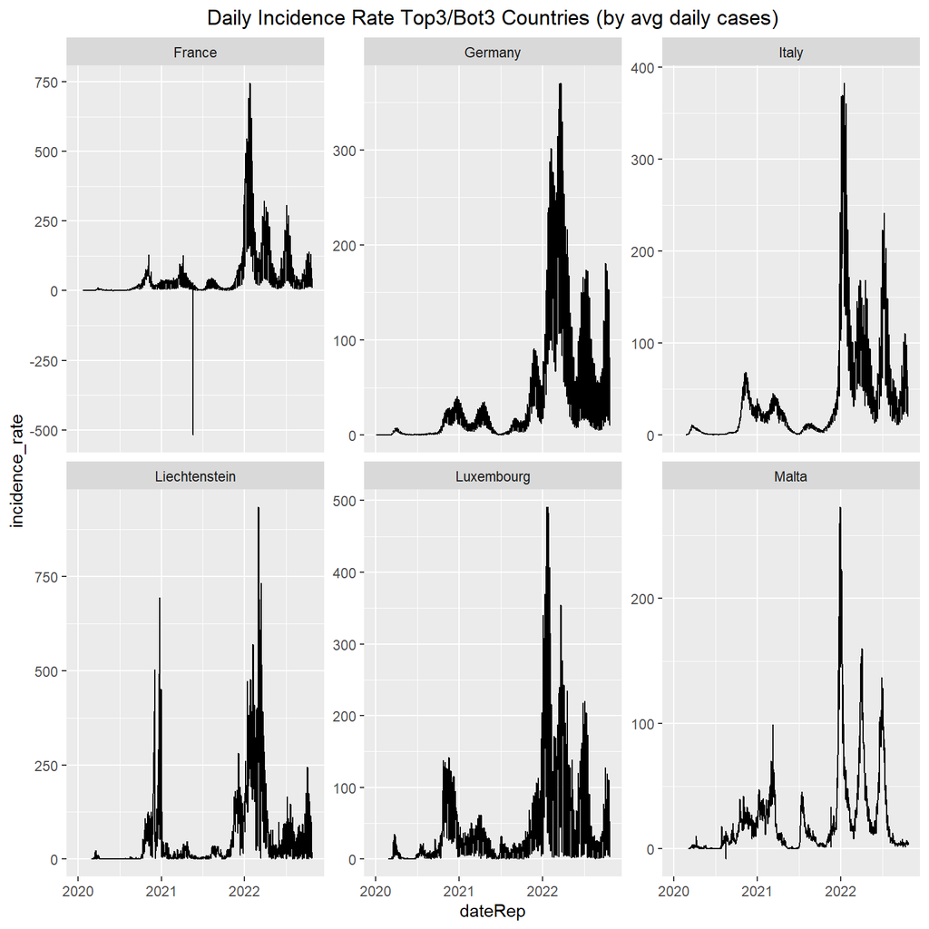

```r
data$incidence_rate <- (data$cases/data$popData2020) * 100000

data$fatality_rate <- (data$deaths/data$popData2020) * 100000

avgcases_holder <- data %>%
  group_by(countriesAndTerritories) %>%
  summarise(avgdailycases = mean(cases)) %>%
  drop_na()

sorted_avgcases <- avgcases_holder[order(avgcases_holder$avgdailycases,decreasing = TRUE),]

top3avg <- sorted_avgcases[1:3,]

bot3avg <- tail(sorted_avgcases,n=3)

top3_bot3 <- full_join(top3avg, bot3avg)

filtered_data <- data %>%
      filter(countriesAndTerritories %in% top3_bot3$countriesAndTerritories)

cases_plot <- ggplot(data=filtered_data, aes(x=dateRep,y=incidence_rate)) +
  geom_line() +
  facet_wrap(~countriesAndTerritories,ncol=3,nrow=2,scales = "free_y") +
  labs(title = 'Daily Incidence Rate Top3/Bot3 Countries (by avg daily cases)') +
  theme(plot.title = element_text(hjust = 0.5))

cases_plot
```

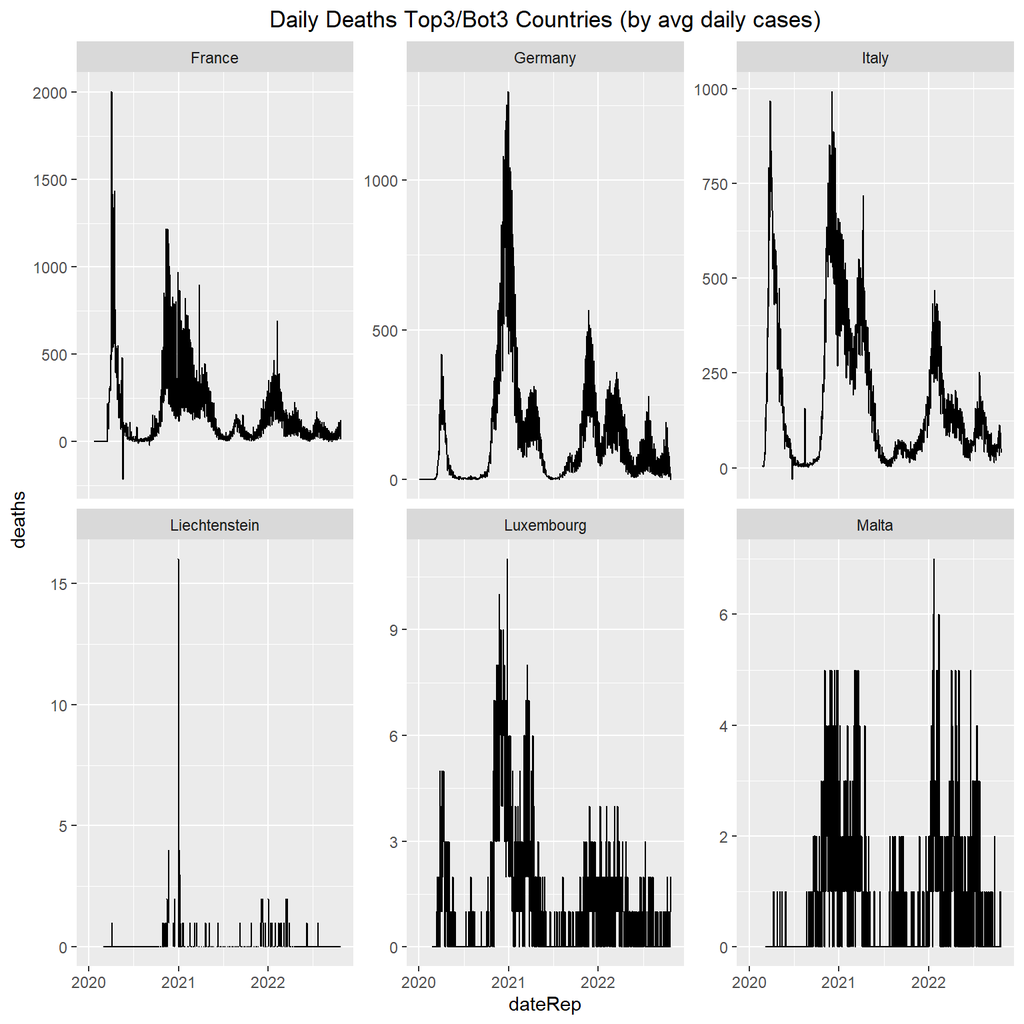

```r
fatality_plot <- ggplot(data=filtered_data, aes(x=dateRep,y=deaths)) +
  geom_line() +
  facet_wrap(~countriesAndTerritories,ncol=3,nrow=2,scales = "free_y") +
  labs(title = 'Daily Deaths Top3/Bot3 Countries (by avg daily cases)') +
  theme(plot.title = element_text(hjust = 0.5))

fatality_plot
```

#### 2. Inferential Statistics

Select two (2) countries of your choosing and compare their incidence or fatality rates using hypothesis testing. At minimum, your work should include the following:

- Visualization(s) comparing the daily incidence or fatality rates of the selected countries,
- A statement of the null hypothesis.
- A short justification of the statistical test selected.
  - Why is the test you selected an appropriate one for the comparison we’re making?
- A brief discussion of any distributional assumptions of that test.
  - Does the statistical test we selected require assumptions about our data?
  - If so, does our data satisfy those assumptions?
- Your selected alpha.
- The test function output; i.e. the R output.
- The relevant confidence interval, if not returned by the R test output.
- A concluding statement on the outcome of the statistical test.
  - i.e. Based on our selected alpha, do we reject or fail to reject our null hypothesis?

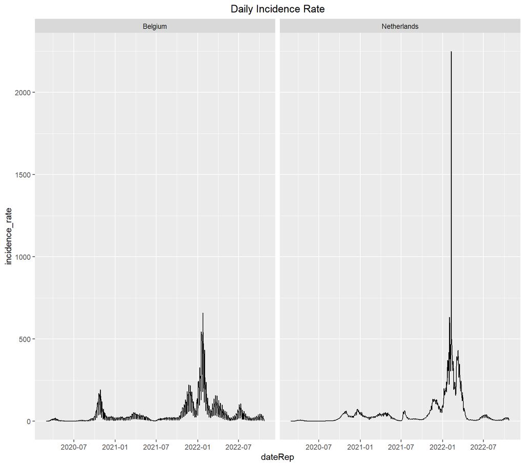

```r
#Let's compare Belgium and Netherlands. Two extremely similar countries culturally and near enough in population size.

country_list <- c("Netherlands","Belgium")

sect2_data <- data %>%
      filter(countriesAndTerritories %in% country_list)

#Our null hypothesis will be that the fatality rates for Belgium and the Netherlands are not significantly different

sect2_cases <- ggplot(data=sect2_data, aes(x=dateRep,y=incidence_rate)) +
  geom_line() +
  facet_wrap(~countriesAndTerritories,ncol=2) +
  labs(title = 'Daily Incidence Rate') +
  theme(plot.title = element_text(hjust = 0.5))

sect2_cases
```

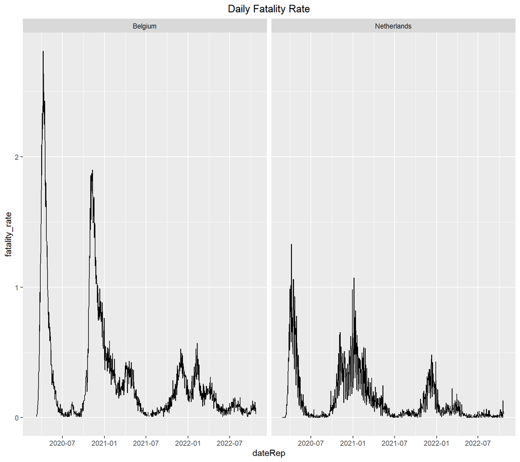

```r
sect2_deaths <- ggplot(data=sect2_data, aes(x=dateRep,y=fatality_rate)) +
  geom_line() +
  facet_wrap(~countriesAndTerritories,ncol=2) +
  labs(title = 'Daily Fatality Rate') +
  theme(plot.title = element_text(hjust = 0.5))

sect2_deaths
```

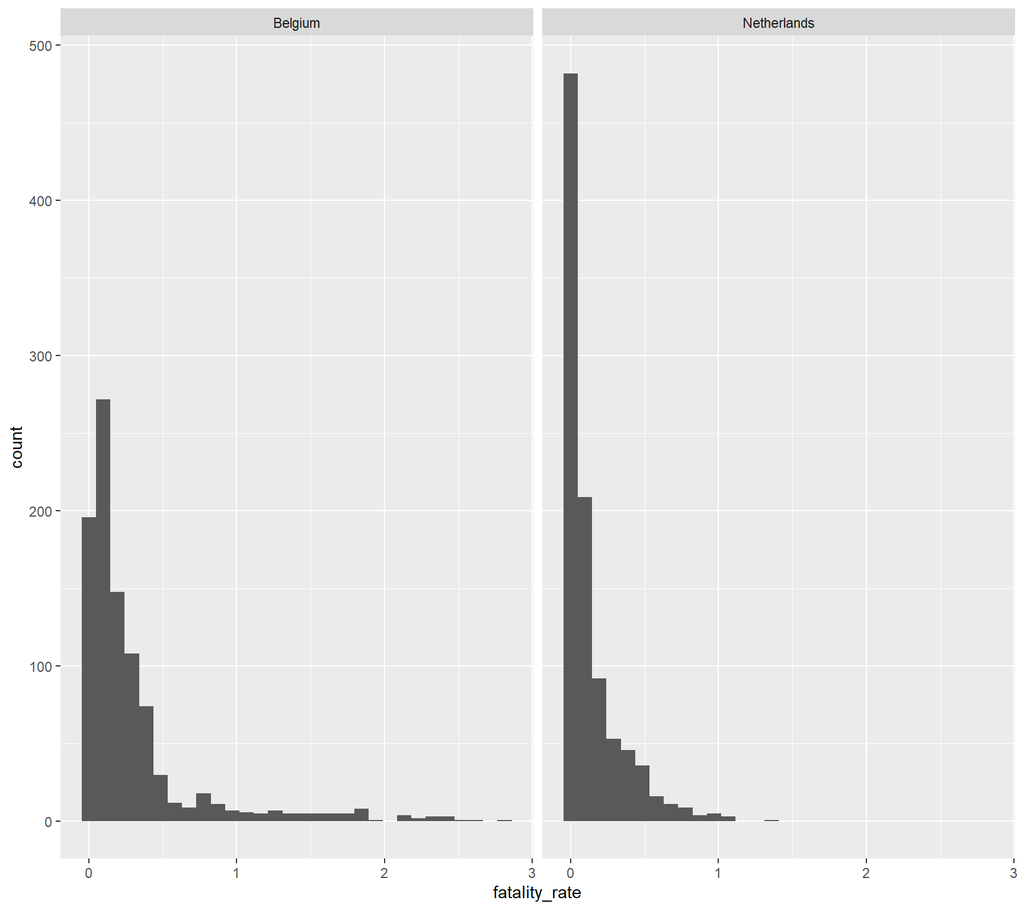

```r
fatality_hist <- ggplot(data=sect2_data, aes(x=fatality_rate)) +
  geom_histogram() +
  facet_wrap(~countriesAndTerritories,ncol=2)

fatality_hist
```

```r
#even though our data is not normally distributed we can still ram through a paired t test. we'll acknowledge that the results shouldn't be taken seriously.
#our focus is to evaluate the means for Belgium and Netherlands against each other to see if for the entire time period, there is a difference.
#a better test would be comparing the relationship between incidence/fatality belgium vs netherlands
#I'm sure there's a better test for time series data


#get the dates since we have a different # of records 967 vs 968 and for slightly different ranges

nl_dates <- sect2_data$dateRep[sect2_data$countriesAndTerritories == "Netherlands"]
belgium_dates <- sect2_data$dateRep[sect2_data$countriesAndTerritories == "Belgium"]

min_nl <- min(nl_dates)
min_bel <- min(belgium_dates)

max_nl <- max(nl_dates)
max_bel <- max(belgium_dates)

sect2_data_datefiltered <- sect2_data %>%
      filter((between(dateRep, min_bel, max_nl)))


nl_data <- sect2_data_datefiltered$fatality_rate[sect2_data_datefiltered$countriesAndTerritories == "Netherlands"]
belgium_data <- sect2_data_datefiltered$fatality_rate[sect2_data_datefiltered$countriesAndTerritories == "Belgium"]

test_results <- t.test(x = nl_data,belgium_data, paired = TRUE)

test_results
```

```
##
##  Paired t-test
##
## data:  nl_data and belgium_data
## t = -16.225, df = 948, p-value < 2.2e-16
## alternative hypothesis: true mean difference is not equal to 0
## 95 percent confidence interval:
##  -0.1825025 -0.1431185
## sample estimates:
## mean difference
##      -0.1628105
```

```r
#so looking at everything so far, we can see that the test does return a tiny p-value < 0.05. But since we really violated the normal distribution assumption, I'm not very confident about this.

skewness(nl_data)
```

```
## [1] 2.273718
```

```r
skewness(belgium_data, na.rm = TRUE)
```

```
## [1] 2.859205
```

#### 3. Correlation

Considering all countries, explore the relationship between incidence rates and fatality rates. At minimum, your work should include the following:

- Visualization(s) showing the distributions of daily incidence and fatality rates, regardless of country. Please note that both country and date should be disregarded here.
- A short statement identifying the most appropriate correlation coefficient.
  - For the correlation we’re interested in, which correlation coefficient is most appropriate?
  - Why do you find the correlation coefficient selected to be the most appropriate?
- The calculated correlation coefficient or coefficient test output; e.g. *cor()* or *cor.test()*.

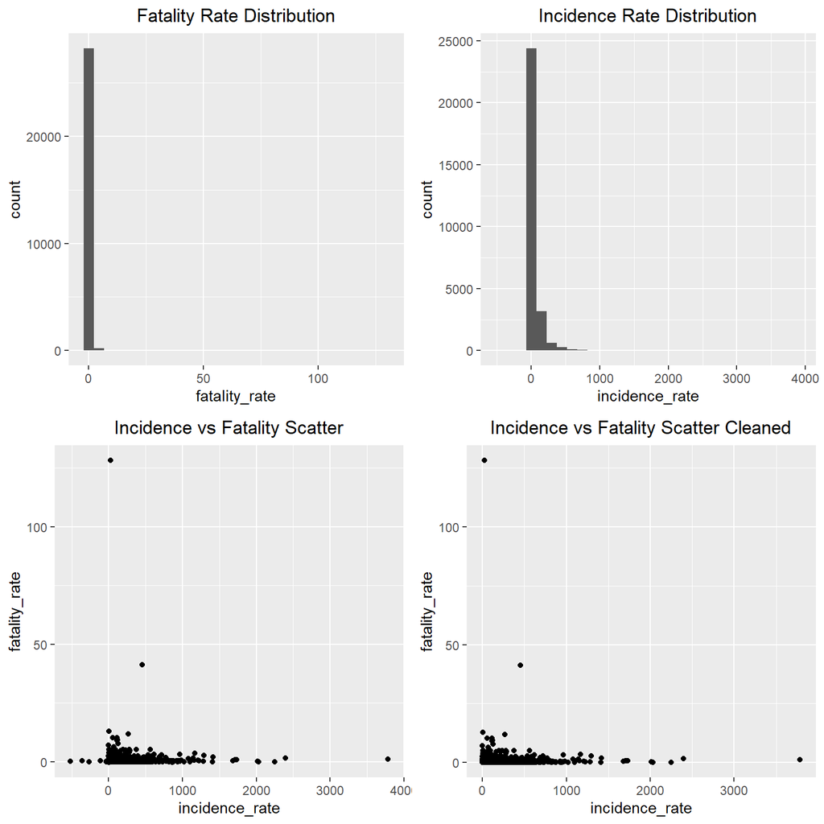

```r
sect3_fatality <- ggplot(data=data, aes(x=fatality_rate)) +
  geom_histogram() +
  labs(title = 'Fatality Rate Distribution') +
  theme(plot.title = element_text(hjust = 0.5))


sect3_incidence <- ggplot(data=data, aes(x=incidence_rate)) +
  geom_histogram() +
  labs(title = 'Incidence Rate Distribution') +
  theme(plot.title = element_text(hjust = 0.5))


sect3_scatter <- ggplot(data=data, aes(x=incidence_rate,y=fatality_rate)) +
  geom_point() +
  labs(title = 'Incidence vs Fatality Scatter') +
  theme(plot.title = element_text(hjust = 0.5))


#the scatter looks bad, I'll drop negatives. Dropping outliers drops a signifcant chunk of data. Since COVID infections/deaths have a huge number of factors and the underlying data is a little suspicious anyway,we're not going to consider any non-negative rates as outliers.

sect3_data <- data[data$incidence_rate >= 0,]

sect3_data <- sect3_data[sect3_data$fatality_rate >= 0,]

sect3_scatter2 <- ggplot(data=sect3_data, aes(x=incidence_rate,y=fatality_rate)) +
  geom_point() +
  labs(title = 'Incidence vs Fatality Scatter Cleaned') +
  theme(plot.title = element_text(hjust = 0.5))



grid.arrange(sect3_fatality,sect3_incidence,sect3_scatter,sect3_scatter2,nrow=2,ncol=2)
```

```r
#for this analysis we should use the r coefficient, the Pearson product-moment correlation coefficient. It'll tell us how strongly correlated Incidence is to Fatality.

cor.test(sect3_data$incidence_rate, sect3_data$fatality_rate,
         alternative = c("two.sided"),
         method = c("pearson"),
         conf.level = 0.95)
```

```
##
##  Pearson's product-moment correlation
##
## data:  sect3_data$incidence_rate and sect3_data$fatality_rate
## t = 19.134, df = 28311, p-value < 2.2e-16
## alternative hypothesis: true correlation is not equal to 0
## 95 percent confidence interval:
##  0.1014746 0.1244736
## sample estimates:
##       cor
## 0.1129893
```

```r
# we use pearson since we assume normal distribution for this analysis. Kendall/Spearman wouldn't really fit since we're assuming a linear relationship. If we were looking for directionally, I think we could put in Kendall/Spearman.
# We can see the coefficient is pretty low at .11, even if we removed outliers the number is not much better.
```